# Election_Analysis_SC

Patrick Harley

August 1, 2017

This report examines a dataset concerning 2016 presidential campaign contributions, and corresponding voter information. The state examined is South Carolina. Other geographical, demographic, and polling data were also introduced from separate files.

# Univariate Plots Section

```
## 'data.frame':    64920 obs. of  22 variables:
##  $ cmte_id          : chr  "C00577130" "C00580100" "C00580100" "C00577130" ...
##  $ cand_id          : chr  "P60007168" "P80001571" "P80001571" "P60007168" ...
##  $ cand_nm          : chr  "Sanders, Bernard" "Trump, Donald J." "Trump, Donald J." "Sanders, Bernard" ...
##  $ contbr_nm        : chr  "HAYWOOD, MARTHA" "STANLEY, PHILIP" "THOMAS, LEONARD" "PAVELKA, GRACE" ...
##  $ contbr_city      : chr  "AIKEN" "PROSPERITY" "GASTON" "GREENVILLE" ...
##  $ contbr_st        : chr  "SC" "SC" "SC" "SC" ...
##  $ contbr_zip       : int  298035368 29127 29053 296053061 294553200 297097114 292051939 294128272 294128272 294128272 ...
##  $ contbr_employer  : chr  "NONE" "RETIRED" "RETIRED" "GAGE'S" ...
##  $ contbr_occupation: chr  "NOT EMPLOYED" "RETIRED" "RETIRED" "PRINT DESIGNER" ...
##  $ contb_receipt_amt: num  50 53.5 51.1 15 51.5 ...
##  $ contb_receipt_dt : chr  "03/05/16" "08/29/16" "09/07/16" "03/05/16" ...
##  $ receipt_desc     : chr  "" "" "" "" ...
##  $ memo_cd          : chr  "" "X" "X" "" ...
##  $ memo_text        : chr  "* EARMARKED CONTRIBUTION: SEE BELOW" "" "" "* EARMARKED CONTRIBUTION: SEE BELOW" ...
##  $ form_tp          : chr  "SA17A" "SA18" "SA18" "SA17A" ...
##  $ file_num         : int  1077404 1146165 1146165 1077404 1091718 1091718 1144666 1144564 1144564 1144564 ...
##  $ tran_id          : chr  "VPF7BKY3804" "SA18.165928" "SA18.170724" "VPF7BKX6V45" ...
##  $ election_tp      : chr  "P2016" "G2016" "G2016" "P2016" ...
##  $ zip              : chr  "29803" "29127" "29053" "29605" ...
##  $ date             : Date, format: "0016-03-05" "0016-08-29" ...
##  $ county           : Factor w/ 46 levels "Abbeville","Aiken",..: 2 36 32 23 10 13 40 10 10 10 ...
##  $ party            : Factor w/ 5 levels "Democrat","Green",..: 1 5 5 1 1 1 1 1 1 1 ...
```

The data was pre-processed to: (a) Extract negative/zero contributions, as these are usually ones that are returned. (b) Normalize zip codes to 5 digits. (c) Add a geographical variable (county of contributor) and a variable for candidate (political) party.

There are 64,920 observations, and 22 variables, though not all are conducive to meaningful analysis. In fact, the only significant numerical variable in the data as originally loaded is the contribution amount. Summary statistics:

```
##     Min.  1st Qu.   Median     Mean  3rd Qu.     Max.
##     0.24    20.00    38.00   142.10   100.00 10000.00
```

Note the wide discrepancy between mean and median, and that the mean is in the 4th quartile. This will require exploration and explanation.

Variables of interest:

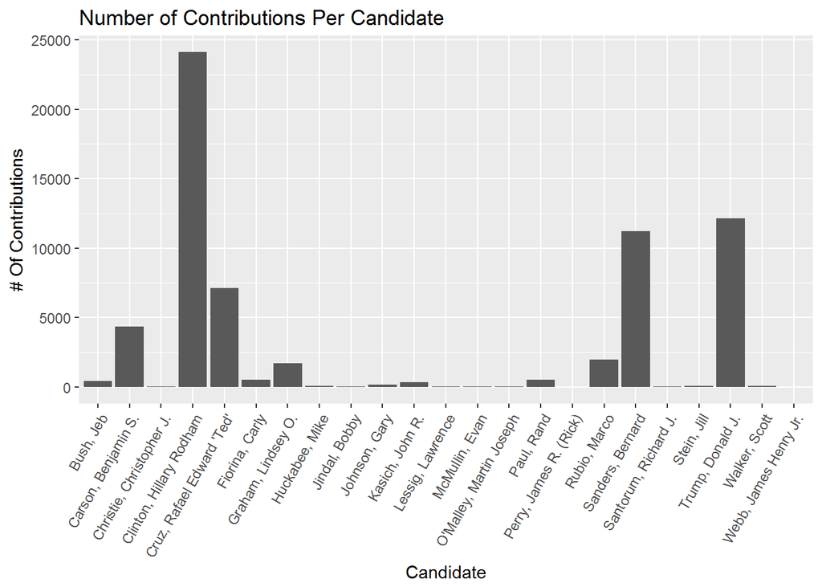

Clinton led the way in total number of contributions.

Contributor cities number 576. Perhaps it’s best to look at the top populous areas in the state. https://en.wikipedia.org/wiki/List_of_cities_and_towns_in_South_Carolina

```
## [1] 0.4580253
```

```
##           contbr_city freq proportion
## 1            COLUMBIA 6998 0.23534555
## 2          CHARLESTON 4802 0.16149319
## 3          GREENVILLE 4153 0.13966706
## 4        MYRTLE BEACH 2017 0.06783252
## 5      MOUNT PLEASANT 1887 0.06346057
## 6               AIKEN 1716 0.05770977
## 7  HILTON HEAD ISLAND 1699 0.05713805
## 8         SUMMERVILLE 1622 0.05454851
## 9         SPARTANBURG 1349 0.04536741
## 10          ROCK HILL 1187 0.03991929
## 11           FLORENCE  885 0.02976291
## 12   NORTH CHARLESTON  663 0.02229696
## 13             SUMTER  383 0.01288044
## 14        GOOSE CREEK  374 0.01257777
```

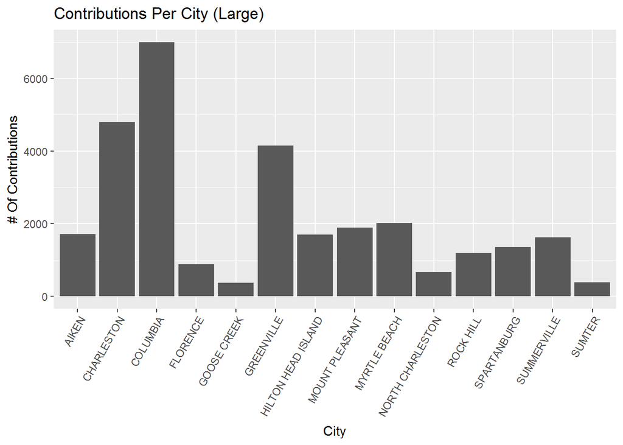

Further exploration of the statistics per city did not provide much value. For this reason, a county variable was added to the main dataframe.

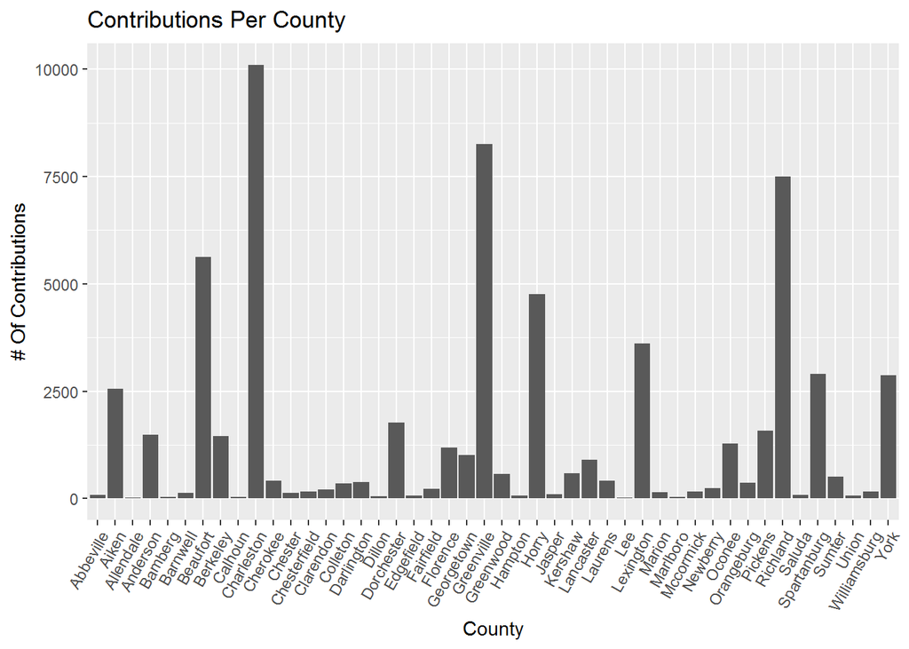

```
##    Min. 1st Qu.  Median    Mean 3rd Qu.    Max.
##      25     112     363    1381    1468   10110
```

```
##          county  freq   proportion
## 1    Charleston 10106 0.1556685151
## 2    Greenville  8255 0.1271565003
## 3      Richland  7495 0.1154497843
## 4      Beaufort  5621 0.0865834874
## 5         Horry  4764 0.0733826248
## 6     Lexington  3616 0.0556993222
## 7   Spartanburg  2897 0.0446241528
## 8          York  2866 0.0441466420
## 9         Aiken  2550 0.0392791128
## 10   Dorchester  1774 0.0273259396
## 11      Pickens  1584 0.0243992606
## 12     Anderson  1489 0.0229359211
## 13     Berkeley  1448 0.0223043746
## 14       Oconee  1284 0.0197781885
```

[output cut: 33 more lines]

Unsurprisingly, the most populous counties had the most contributions. Cumulative amounts raised will be studied more later in the bivariate and multivariate analysis.

A first look at contributions in ranges.

Note: federal law caps individual donations at $2700. In all, 9,227,824 in positive contributions were donated. The distribution is right-tailed, with smaller contributions dominant.

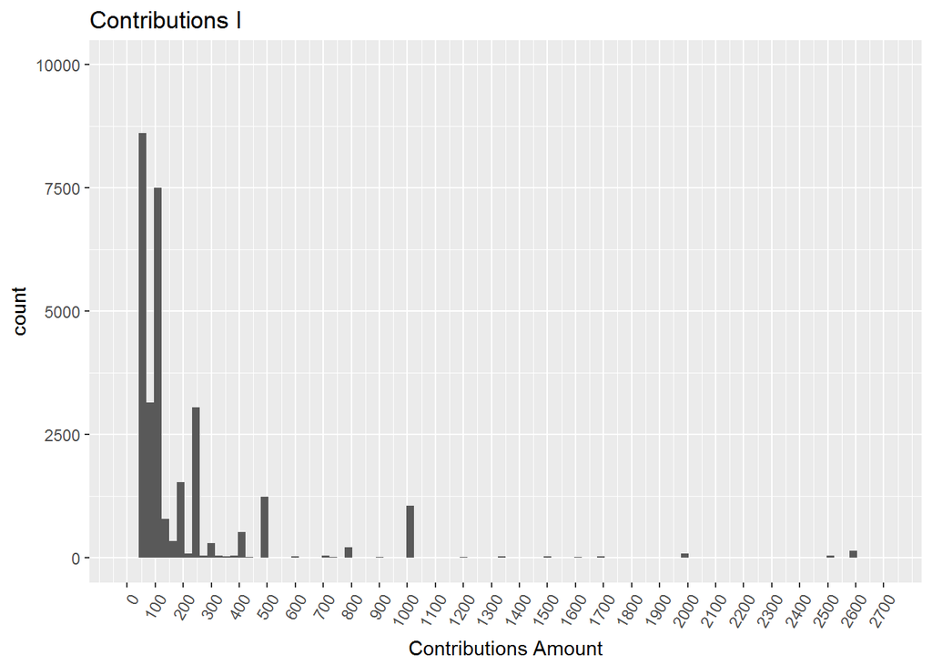

Now, Contributions of $250 or more:

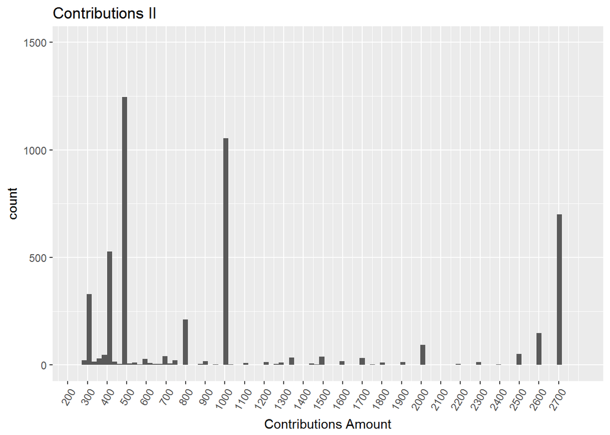

The heavier weights on this last graph gives a better sense of the following reality. The sum of all contributions less than $250:

```
## [1] 2658737
```

Greater than or equal to $250:

```
## [1] 6569087
```

A variable was also added for party of the contribution recipient.

```
##         party  freq   proportion
## 1    Democrat 35384 0.5450400493
## 2  Republican 29269 0.4508471965
## 3 Libertarian   146 0.0022489217
## 4       Green    97 0.0014941466
## 5 Independent    24 0.0003696858
```

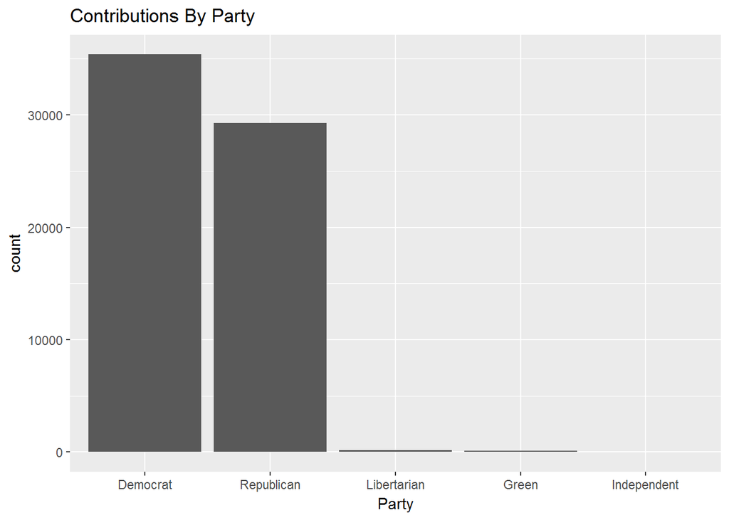

The total number of contributions favored the democrats. But as will be seen, the total amount raised was a different story.

There was also a rough consolidation taken across the occupation column, organized by industry

```
##                 Industry freq
## 1                Medical 6307
## 2            Unenmployed 4276
## 3              Education 3471
## 4  Consultant-Contractor 2385
## 5   Management-Executive 2371
## 6    Engineer-IT-Science 2180
## 7              Homemaker 1311
## 8               Creative 1287
## 9         Business Owner 1087
## 10                 Sales  885
## 11               Finance  804
## 12         Self-Employed  746
## 13           Real Estate  742
## 14               Service  551
## 15               Student  433
## 16             Counselor  382
## 17            Technician  357
## 18      Travel-Transport  349
## 19                   Law  348
## 20             Insurance  337
## 21             Marketing  331
## 22              Religion  275
## 23                Office  176
## 24           Social Work  125
## 25            Government   82
## 26                Farmer   73
```

The date of each contribution was also provided. A timeline:

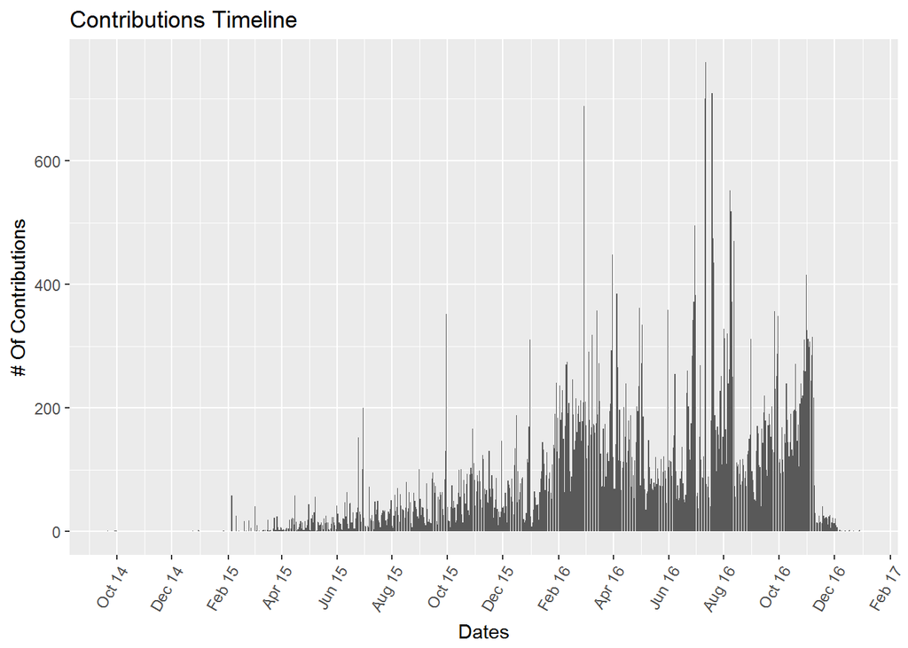

By Month:

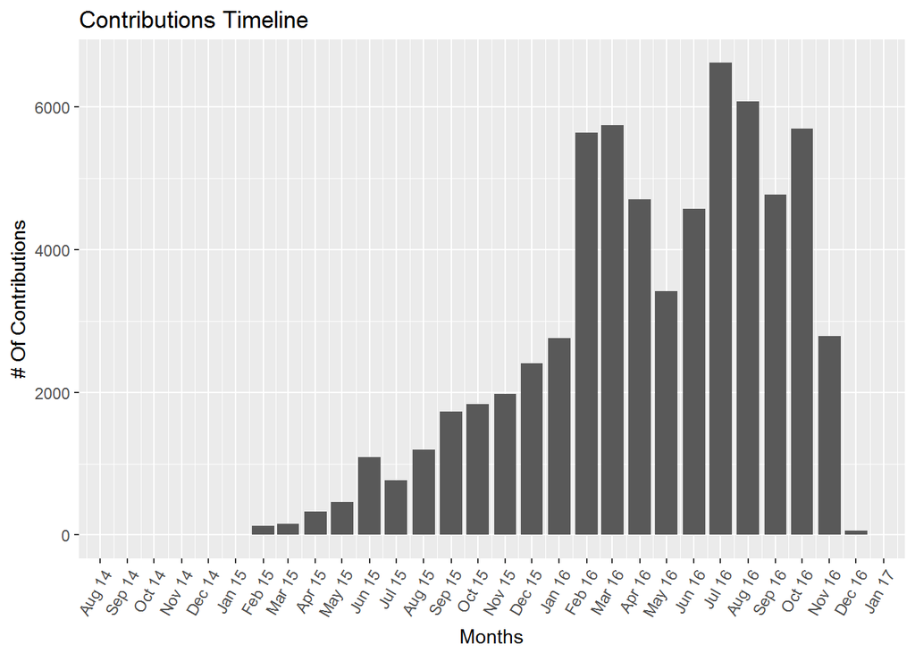

# Univariate Analysis

After removing returned (negative) contributions, there are 64,920 contributions in the principal dataset.

In this phase, the main features in the dataset are contribution amounts, party and geographical clustering (of contributions). Some attention will also be paid to contributor occupations, gathered into industry. I’d like to find out what factors predict total contributions in different areas of the state. Good predictors will likely be population and income (which will be introduced).

The timeline is also crucial for exploring the data, as there are different phases: primary (with sub-phases as different candidates rise and fall, and the field thins) and general election. It should be especially interesting to see the progression of Trump contributions, as the perception of his candidacy became more viable.

I created “clean” variables for zip code and contribution dates. The normalized zip codes were used with an external file to add a county variable. A party variable was added as well.

In the analysis of contribution amounts, different “looks” (limits, binwidths) at amount ranges were used to extract meaningful analysis of the right-tailed distribution. I also refined the contributions timeline to month after the original by-date graph.

# Bivariate Plots

First we’ll look at the relationship between candidates and the variable receipt totals, and corresponding statistics. Given the nominal sums donated to the 3rd party and independent candidates, I wanted to focus on the Republican-Democrat matchup.

```
## # A tibble: 20 × 3
##                      cand_nm      total     n
##                        <chr>      <dbl> <int>
## 1    Clinton, Hillary Rodham 2323836.44 24116
## 2           Trump, Donald J. 1844054.78 12146
## 3         Graham, Lindsey O. 1815687.05  1688
## 4  Cruz, Rafael Edward 'Ted'  747026.91  7109
## 5               Rubio, Marco  729870.48  1966
## 6        Carson, Benjamin S.  517150.49  4329
## 7           Sanders, Bernard  492722.91 11196
## 8                  Bush, Jeb  317715.08   425
## 9            Kasich, John R.  102708.50   325
## 10                Paul, Rand   80739.89   508
## 11            Fiorina, Carly   73116.76   510
## 12      Santorum, Richard J.   49219.44    53
## 13             Walker, Scott   24197.00    75
## 14   O'Malley, Martin Joseph   18740.00    41
## 15            Huckabee, Mike   18232.00    95
## 16  Christie, Christopher J.    9050.00    25
## 17          Lessig, Lawrence    4448.83    25
## 18             Jindal, Bobby    2061.26    11
## 19     Webb, James Henry Jr.    2000.00     6
## 20    Perry, James R. (Rick)     775.00     4
```

```
##    Min. 1st Qu.  Median    Mean 3rd Qu.    Max.
##     775   15940   76930  458700  570300 2324000
```

It makes sense to look at the candidate totals by party, and before the primary, when so many were eliminated.

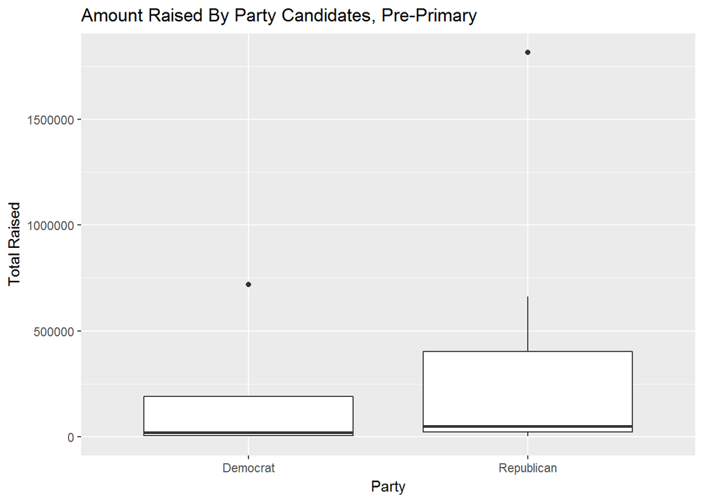

The democratic ‘outlier’ is Clinton, who had a big fundraising edge on the rest of the field. For the GOP, Lindsey Graham, who had favorite son status as a SC Senator, was the outlier on the right. He raised over $1.8m only to withdraw from the primary. Presumably, Graham was able to rely on big donors within the state, judging from mean contributions (arranged in descending order):

```
## Source: local data frame [20 x 5]
## Groups: party [2]
##
##         party                   cand_nm      total       mean     n
##        <fctr>                     <chr>      <dbl>      <dbl> <int>
## 1  Republican        Graham, Lindsey O. 1815687.05 1075.64399  1688
## 2  Republican      Santorum, Richard J.   49219.44  928.66868    53
## 3  Republican                 Bush, Jeb  317665.08  749.21009   424
## 4  Republican           Kasich, John R.   48046.00  500.47917    96
## 5    Democrat   O'Malley, Martin Joseph   18740.00  457.07317    41
## 6  Republican              Rubio, Marco  661968.32  443.67850  1492
## 7  Republican  Christie, Christopher J.    9050.00  362.00000    25
## 8  Republican             Walker, Scott   23362.00  333.74286    70
## 9    Democrat     Webb, James Henry Jr.    2000.00  333.33333     6
## 10 Republican          Trump, Donald J.   43695.68  323.67170   135
## 11   Democrat   Clinton, Hillary Rodham  719060.00  274.55517  2619
## 12 Republican            Huckabee, Mike   17842.00  205.08046    87
## 13 Republican    Perry, James R. (Rick)     775.00  193.75000     4
## 14 Republican             Jindal, Bobby    2061.26  187.38727    11
## 15   Democrat          Lessig, Lawrence    4448.83  177.95320    25
## 16 Republican                Paul, Rand   80689.89  159.15166   507
## 17 Republican Cruz, Rafael Edward 'Ted'  515039.39  144.47108  3565
## 18 Republican            Fiorina, Carly   73116.76  143.36620   510
## 19 Republican       Carson, Benjamin S.  486487.11  124.23062  3916
## 20   Democrat          Sanders, Bernard  190370.83   62.76651  3033
```

Totals raised by the GOP candidates, the winner (Trump) is shown in black:

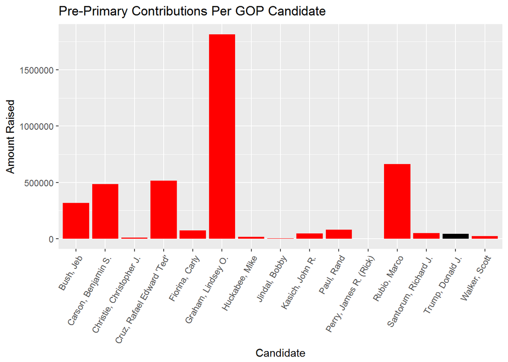

Now we check for correlation between amount raised in this period, and primary showing as a percentage:

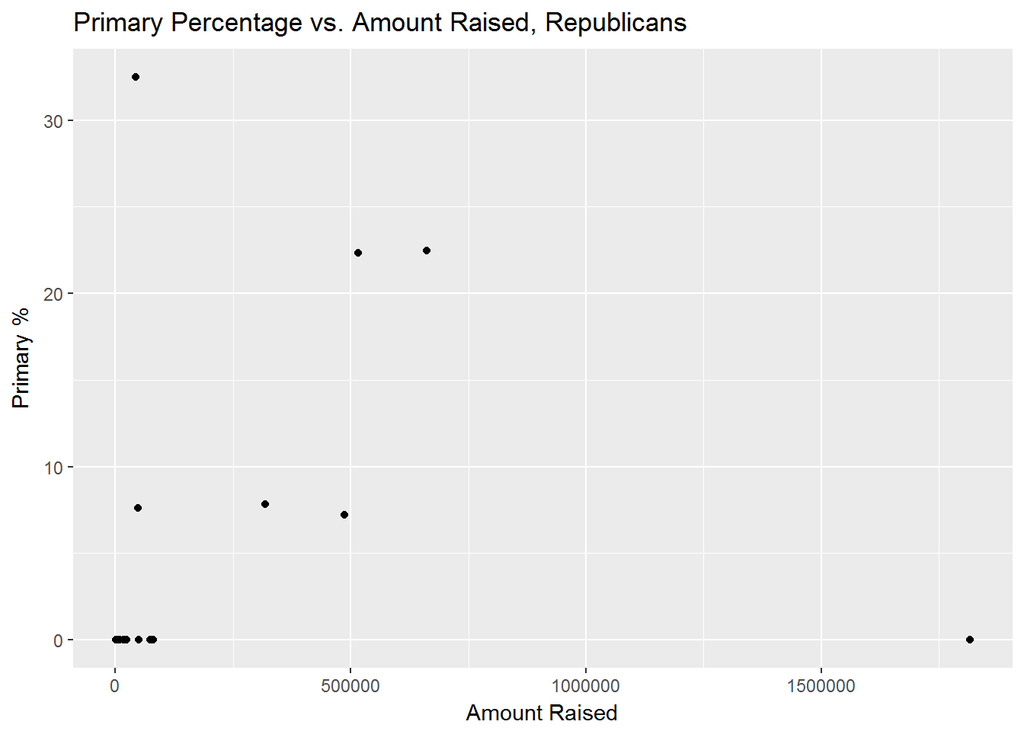

```
## [1] 0.09228098
```

This paints an unexpected picture of the relationship between money and results: in the ’16 SC primary, they didn’t matter much on the Republican side. It’s probable that Trump’s high celebrity visibility nullified the fundraising deficit.

Though looking at the entire set of contributions:

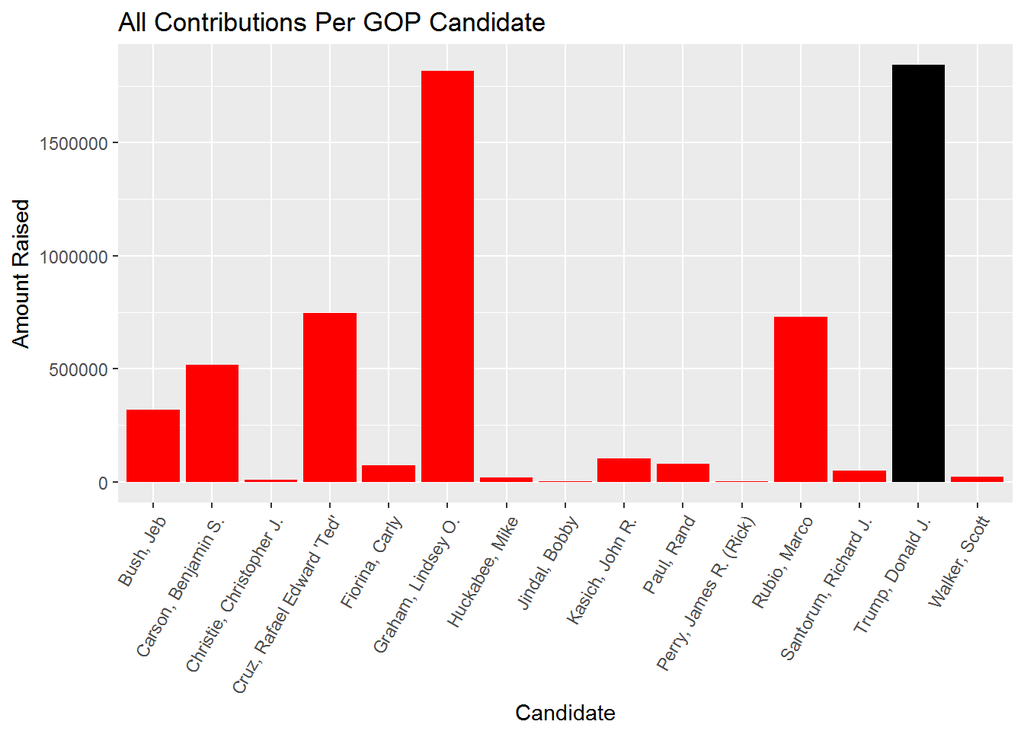

Trump was successful raising money after the primary. Later we’ll look at the head-to-head with Clinton after each had secured their nominations.

On the democratic side, only Sanders and Clinton received more than 1% of the vote. O’Malley had 713 among the other candidates who garnered any contributions (Lessig and Webb had withdrawn).

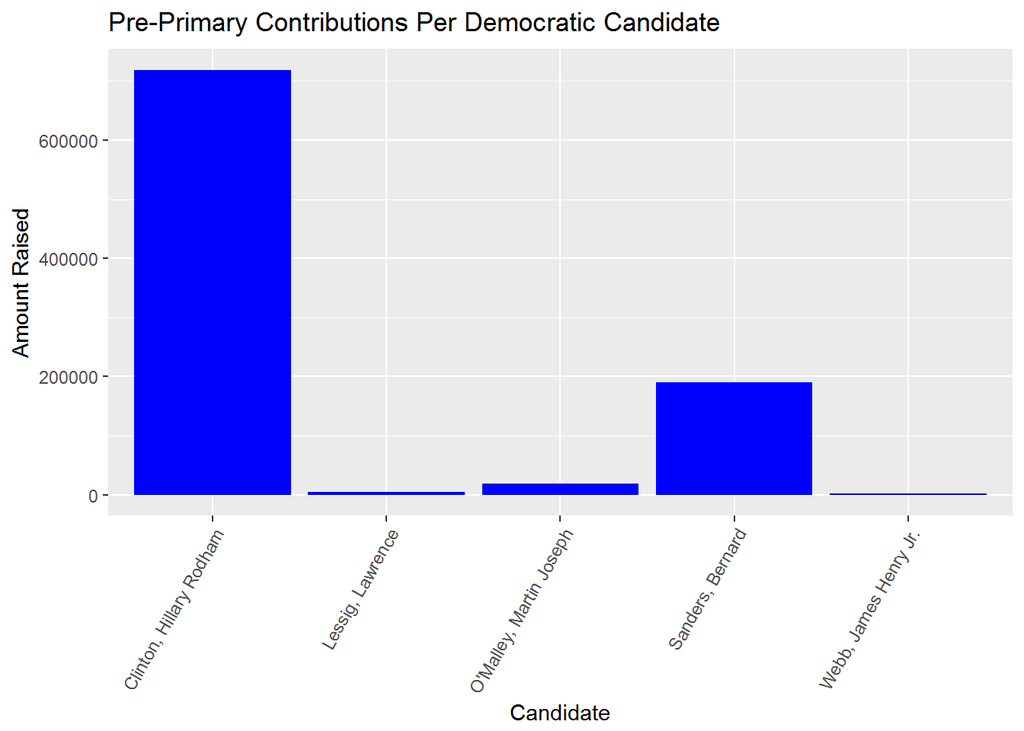

This directly correlated to the primary results:

```
## [1] 0.9948218
```

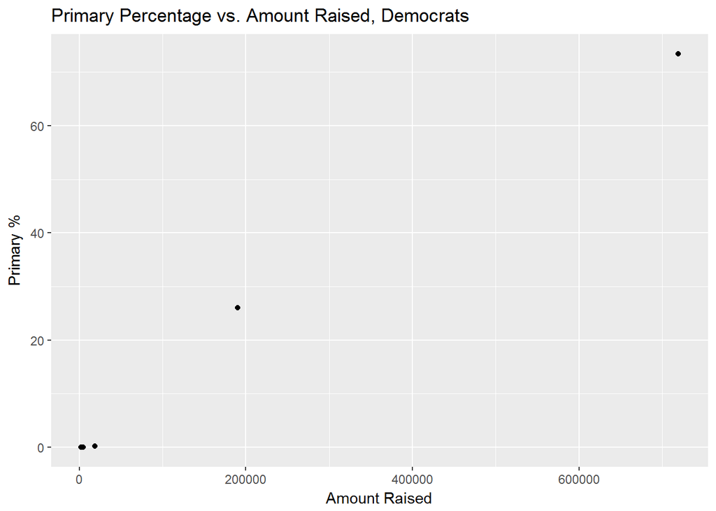

Next I augmented the county data with demographic information: population, median and per capita income, looking for correlations.

Population:

```
## [1] 0.8621631
```

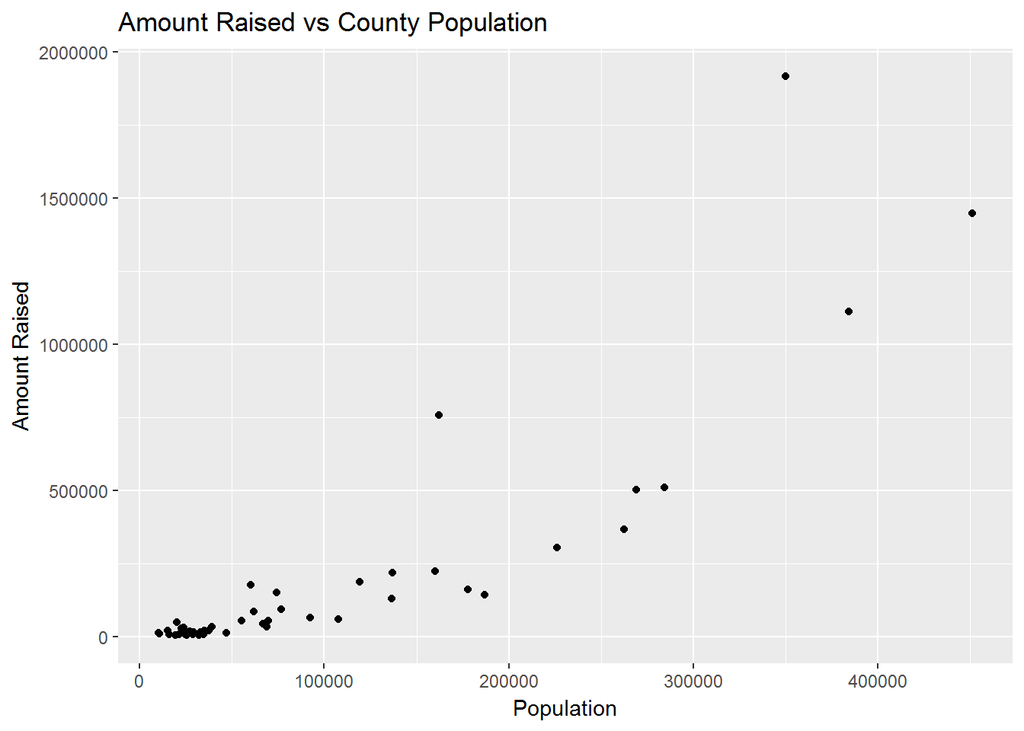

Population was the strongest predictor of the 3.

Median Income:

```
## [1] 0.5243177
```

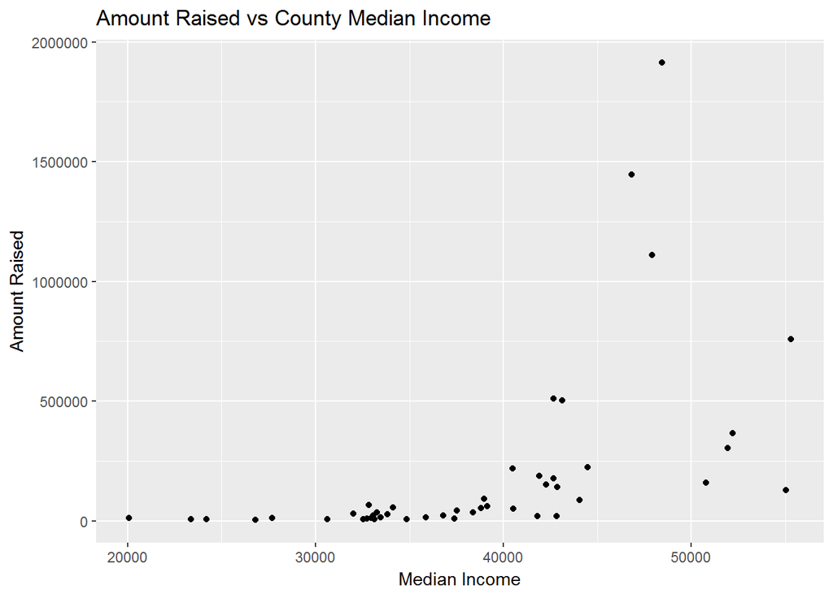

Per capita income was a stronger predictor than median:

```
## [1] 0.6901518
```

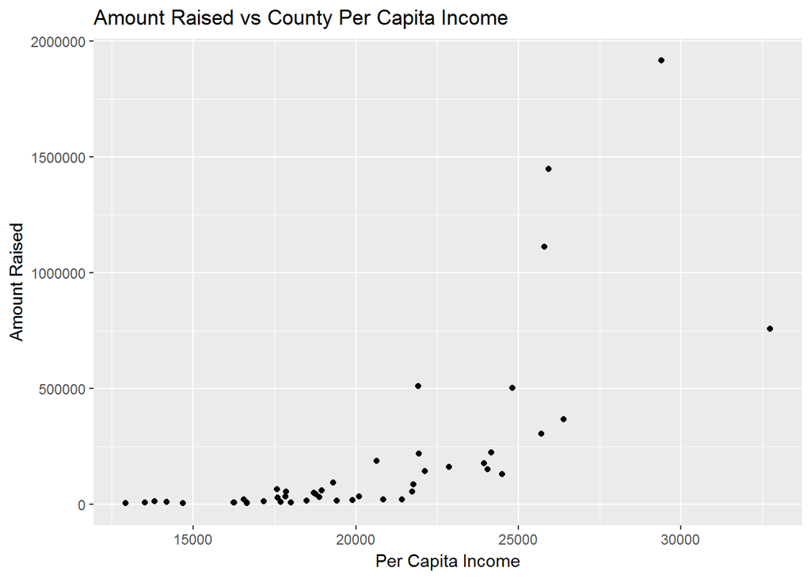

# Bivariate Analysis

Weighing the relationship between total contributions amount, and primary results, the large sums raised by native son Lindsey Graham and the other GOP contenders did not correlate with success. The winner, Donald Trump, was far behind in total raised (though he made up for it later), but still won the primary. The correlation between amount raised and primary results on the Democratic side was very strong.

# Multivariate Plots

Next, I looked for trends by contribution totals, county, and party.

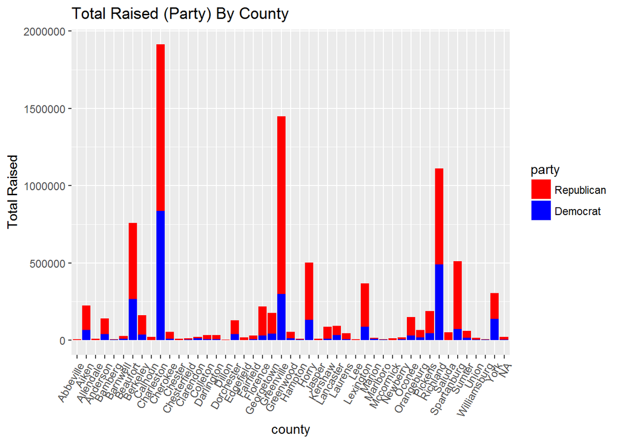

[figure not shown]

This needs a more strict geographical approach. I used the choroplethr packages to construct density maps:

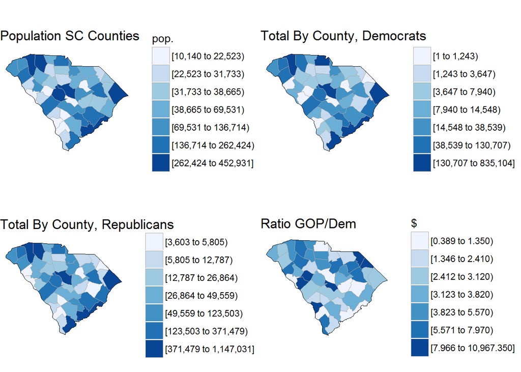

The separate democratic and Republican maps resemble the population map, this will be explored more precisely below. The last map, ratio of Republican/Democratic contributions per county is the most indicative of qualitative factors: the white regions are where the Democrats either won or were close, and are clustered near the middle of the state or on the coast. The upstate has always trended Republican, the ratios are stronger in the Northwest section.

Total raised by county population, with 3rd variable party. The first correlation coefficient is for the Democrats, second for Republicans:

```
## [1] 0.7467582
```

```
## [1] 0.8895627
```

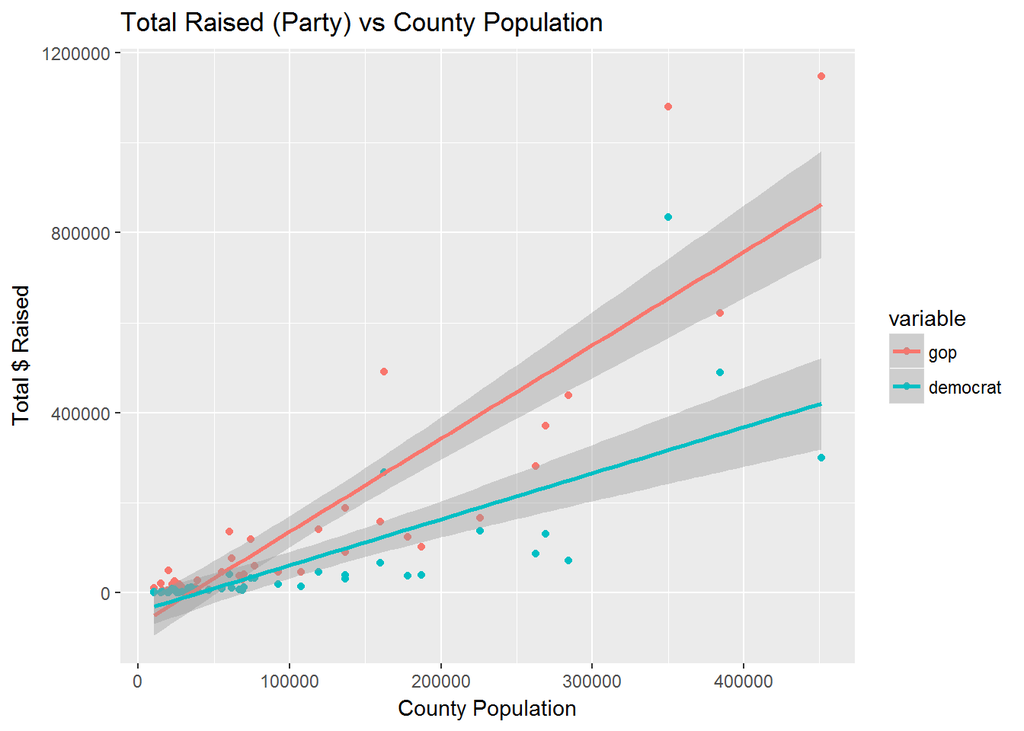

Population is a good predictor for both, but stronger for the GOP.

Attempting to probe the relationship between per capita income and cumulative county contributions, figuring in the extra variable of party:

```
## [1] 0.6378535
```

```
## [1] 0.6884881
```

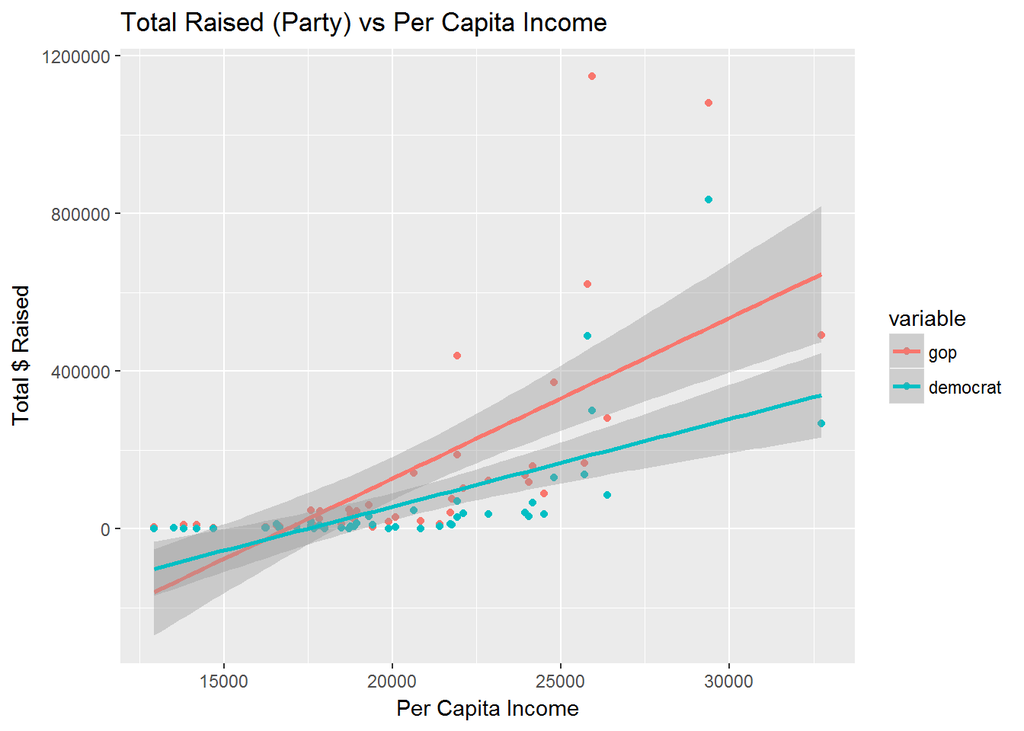

Per capita seems marginally better as a predictor, for the GOP. But one problem with the data as gathered is that income statistics aren’t available *per party*, which makes it hard to ferret out stronger relationships between wealth and average/aggregate contributions.

To gain meaningful insight related to election results and contribution amounts, the values of the variable candidate names (cand_nm) for Trump and Clinton must be looked at more closely, and the date variable as well.

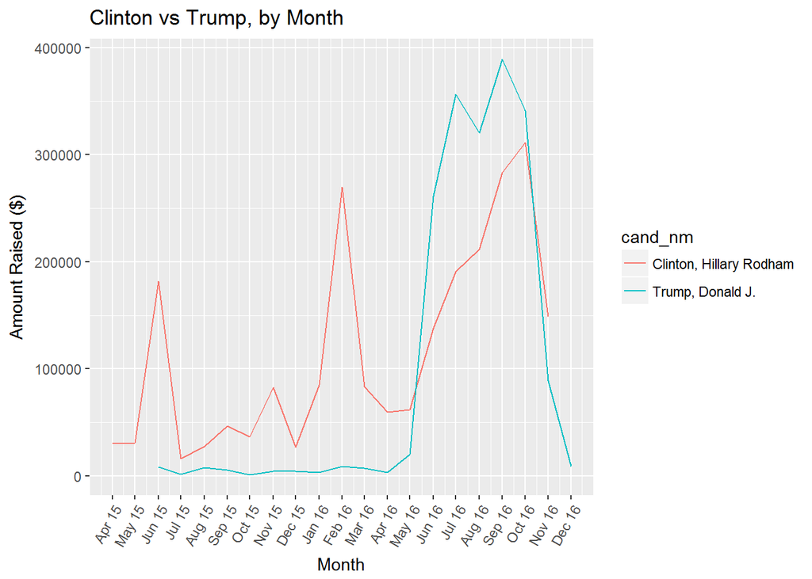

This is expanded upon below.

Finally, a look at industry contributions:

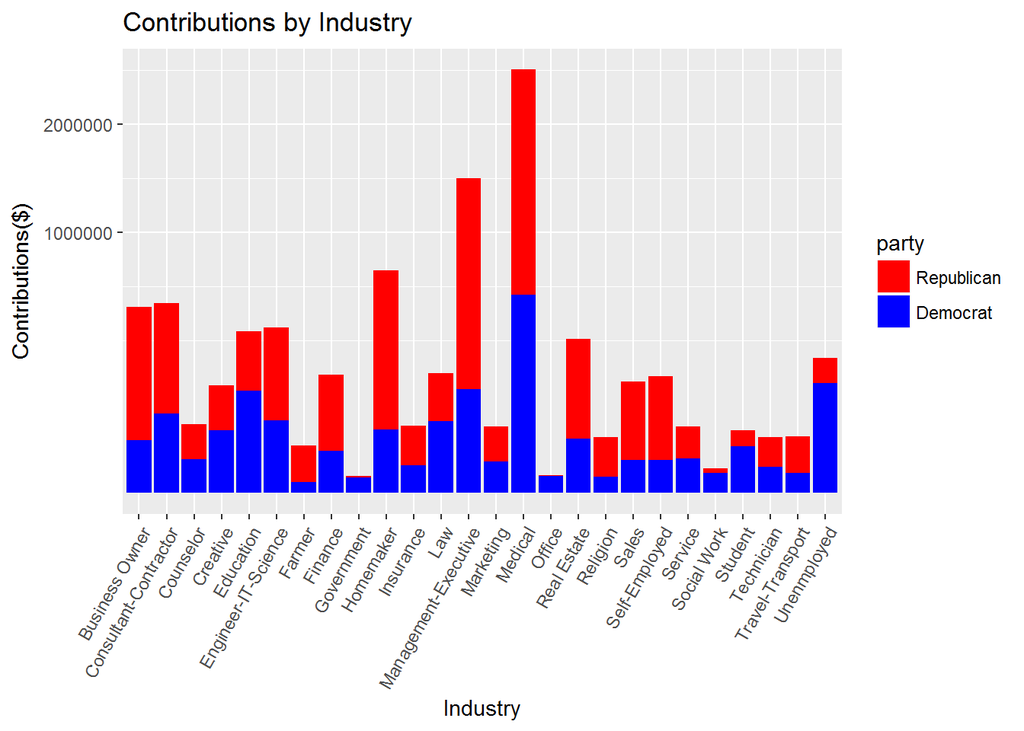

## Multivariate Analysis

Narrowing the candidate variables to the two principals in the general election, time was of the essence. Clinton had solid fund-raising the whole way (earlier we saw whe was the top recipient). But the timeline shows the night-and-day financial support for Trump before-and-after he had secured the nomination. This is perhaps the most surprising graph of the whole analysis, belying the underdog-to-frontrunner status.

There was also a comparison along party and industry lines, which did indicate some trends in support of the separate parties.

# Final Plots and Summary

## Plot 1

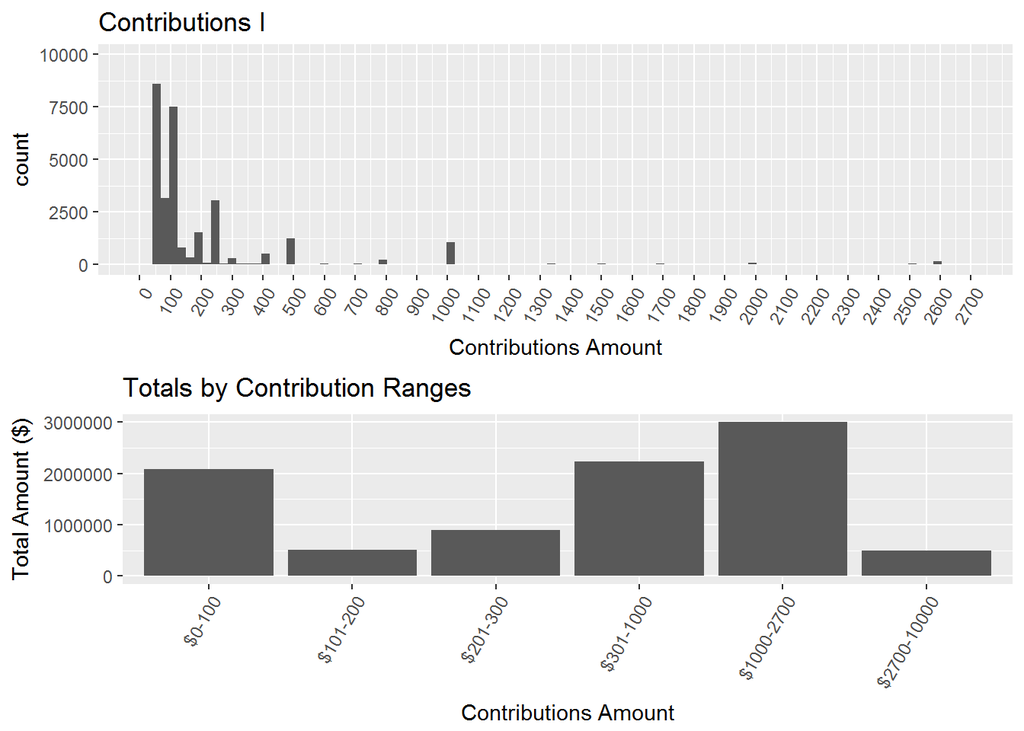

While the contribution receipt amounts are right-tailed, a closer look at the summary statistics showed a median of 38, mean of 142 and a 3rd quartile at 100. As the 2nd graph indicates a larger proportion of the cumulative contribution amounts were from big donors, dragging the mean contribution higher.

## Plot 2

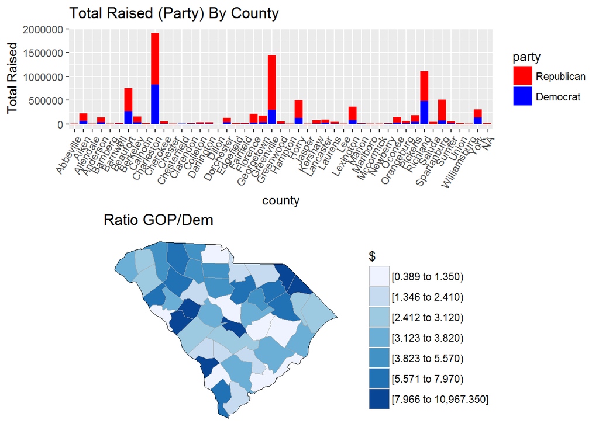

The GOP raised more money across the state, and in most counties. Geographically, the democrats were closer in Richland County and the Charleston area, but the Republicans were dominant in the populous upstate counties like Greenville and Spartanburg.

## Plot 3

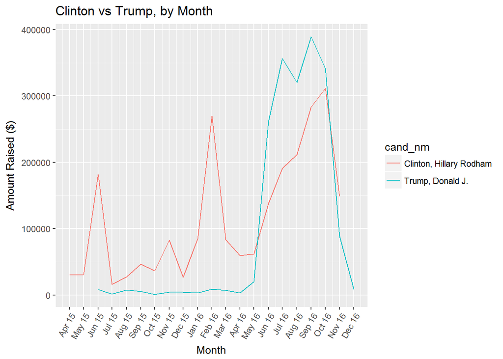

The date variable was crucial as well, and reflects the storylines of the Clinton and Trump campaigns in the state. Clinton led in fundraising through the primary on Feb. 20th, until around the time that Trump clinched the nomination in May, after which he led until the election. The low level of support for Trump was a non-factor in the primary.

# Reflection

The original dataset contained 64,920 positive contributions, after discarding negative ones. There were 22 original variables, not all of which were useful, and some re-shaping was required, in addition to augmenting with several variables. After preliminary analysis, I focused on studying the aggregate contributions by county, by party and candidate, and dates. This latter was important because of the nature of the campaign itself, broken into primary and general election phases.

While small donations made up the vast majority of contributions, in fact larger contributions outweighed them in the cumulative sum. At the county level, the relationship between aggregated contribution amounts at the county level and population was strongest, with some reasonable correlation between amount and per capita income as well. The relationship between amount raised and primary results was meaningless on the GOP side, very strong for the Democrats. Trump won the primary with very little financial support, but overtook Clinton in fundraising in the general election phase.

There are limitations in the dataset, and the resulting analysis. To detect meaningful correlations, extra demographic data was introduced at the county level. Even after detecting a relationship between per capita income and contribution amounts, it was not possible to move forward to more focused analysis (for example per party or even zip code), that would likely be necessary for an analyst hoping to use the data for (say) political ad buys. In addition, the geographical and candidate profiles built are *for this election*, and would not likely be valid for previous/future ones. This is owing to the huge GOP field (usually there is more solidification around 1 or a few candidates), and to the special nature of the outsider campaign run by Trump, which may have pulled in independents around the state. If a political consultant was looking to build better voter and geographical profiles, he/she would likely need to look at a longer timeline of elections, in addition to seeking out more specialized income/other data.